# Untitled

Roman Olenev

2023-12-07

Данные про опоссумов.

```r
dataset23 <- read.csv("C:/Users/roman/Downloads/possum.csv")
dataset23 <- drop_na(dataset23)
```

Стандартизуем данные.

```r
head(dataset23)
```

```
##   case site Pop sex age hdlngth skullw totlngth taill footlgth earconch  eye
## 1    1    1 Vic   m   8    94.1   60.4     89.0  36.0     74.5     54.5 15.2
## 2    2    1 Vic   f   6    92.5   57.6     91.5  36.5     72.5     51.2 16.0
## 3    3    1 Vic   f   6    94.0   60.0     95.5  39.0     75.4     51.9 15.5
## 4    4    1 Vic   f   6    93.2   57.1     92.0  38.0     76.1     52.2 15.2
## 5    5    1 Vic   f   2    91.5   56.3     85.5  36.0     71.0     53.2 15.1
## 6    6    1 Vic   f   1    93.1   54.8     90.5  35.5     73.2     53.6 14.2
##   chest belly
## 1  28.0    36
## 2  28.5    33
## 3  30.0    34
## 4  28.0    34
## 5  28.5    33
## 6  30.0    32
```

```r
dataset2 <- dataset23 %>% select(-c(case,site,Pop,sex))
dataset2 <- data.frame(scale(dataset2, center=TRUE, scale=TRUE))
dataset2_mult <- dataset2 %>% mutate(earconch=earconch*3)
head(dataset2)
```

```
##          age     hdlngth      skullw   totlngth      taill  footlgth  earconch
## 1  2.1816300  0.38914982  1.10859169  0.4123838 -0.5322895 1.3825712 1.5679274
## 2  1.1373427 -0.06556176  0.20614572  1.0080754 -0.2786988 0.9294163 0.7551899
## 3  1.1373427  0.36073035  0.97967084  1.9611820  0.9892550 1.5864909 0.9275888
## 4  1.1373427  0.13337456  0.04499465  1.1272137  0.4820735 1.7450952 1.0014740
## 5 -0.9512321 -0.34975649 -0.21284705 -0.4215845 -0.5322895 0.5895501 1.2477581
## 6 -1.4733757  0.10495508 -0.69630025  0.7697987 -0.7858803 1.0880205 1.3462717
##           eye     chest      belly
## 1  0.14122321 0.4630244  1.2322948
## 2  0.89690770 0.7104607  0.1324853
## 3  0.42460490 1.4527697  0.4990884
## 4  0.14122321 0.4630244  0.4990884
## 5  0.04676265 0.7104607  0.1324853
## 6 -0.80338239 1.4527697 -0.2341179
```

pairplot.

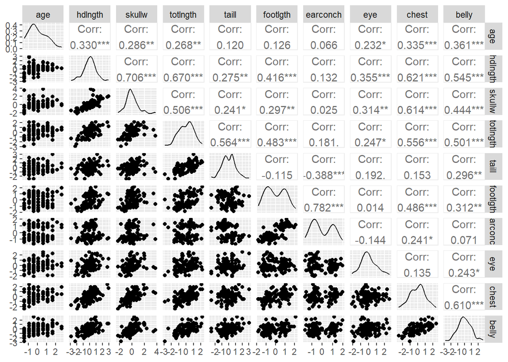

```r
ggpairs(dataset2)
```

PCA для визуализации.

```r
pcaclust2 <- PCA(dataset2)
```

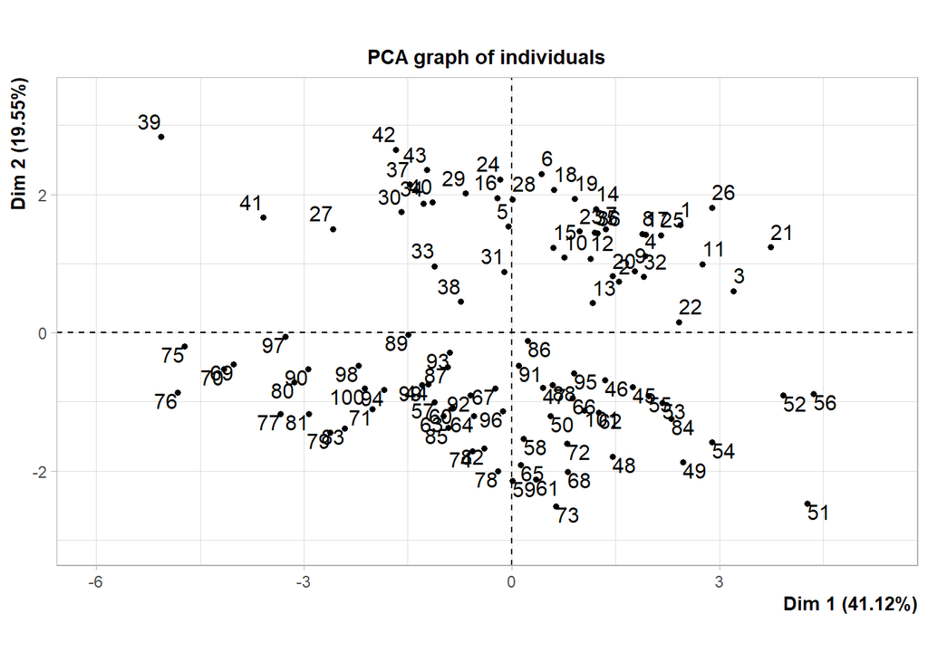

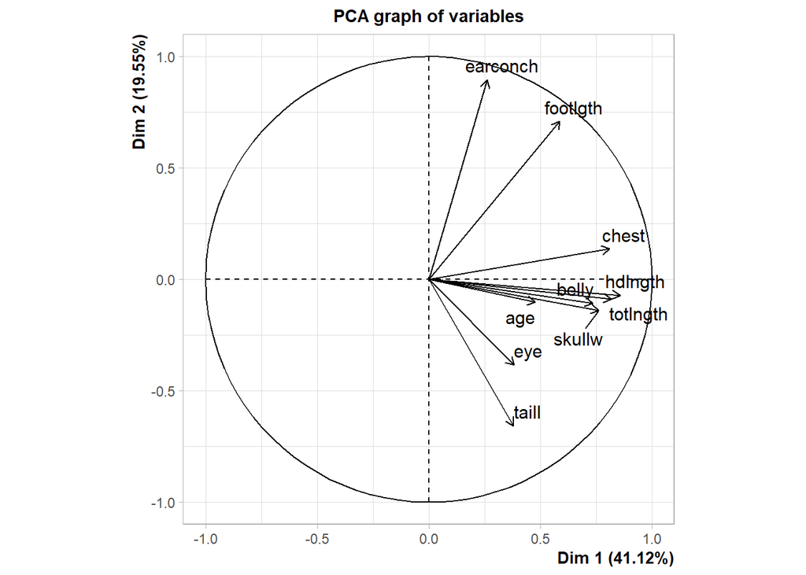

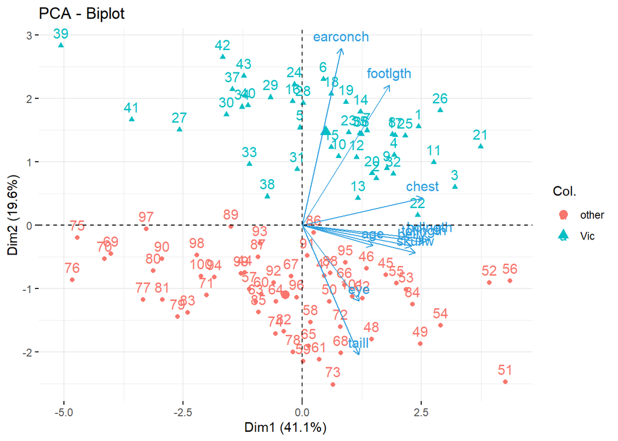

```r
fviz_pca_biplot(pcaclust2, repel = FALSE,
                col.var = "#2E9FDF",
                col.ind = as.factor(dataset23$Pop),
                )
```

K-means для 2 кластеров. Не очень хороший результат - k-means поделил на шарики.

```r
res22 <- kmeans(dataset2, centers=2, iter=100)
```

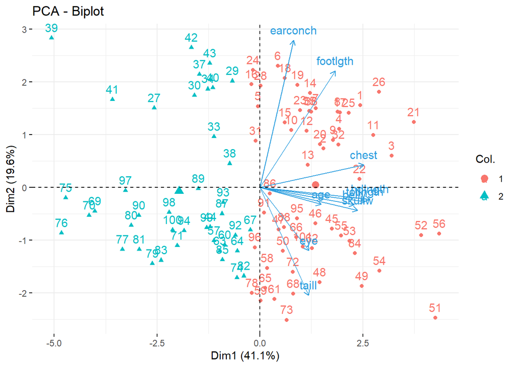

```r
fviz_pca_biplot(pcaclust2, repel = FALSE,
                col.var = "#2E9FDF",
                col.ind = as.factor(res22$cluster),
                )
```

Если умножить признак earconch, по которому сильное отличие, на 3, то получится правильное разделение.

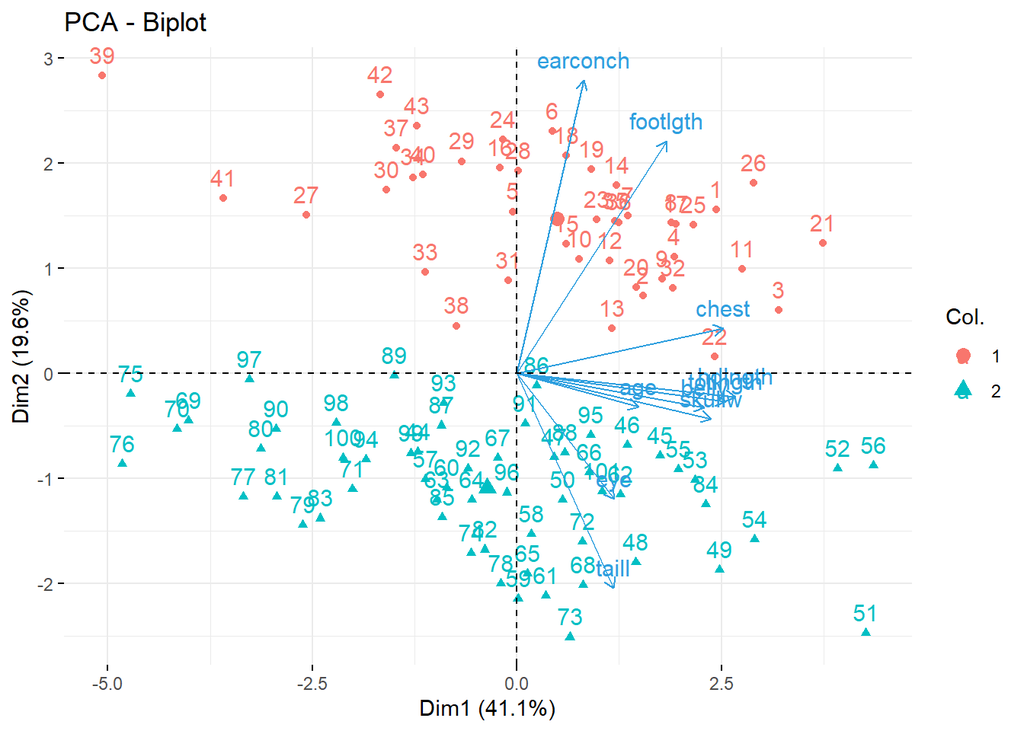

```r
res22_mult <- kmeans(dataset2_mult, centers=2, iter=100)

fviz_pca_biplot(pcaclust2, repel = FALSE,
                col.var = "#2E9FDF",
                col.ind = as.factor(res22_mult$cluster),
                )
```

Иерархическая кластеризация. На вход подается матрица расстояний, в данном случае метрика евклидова. Метод объединения complete, то есть по максимальному расстоянию между кластерами. Получается примерно то же, что и у k-means. Изменение метода объединения не исправляет ситуацию.

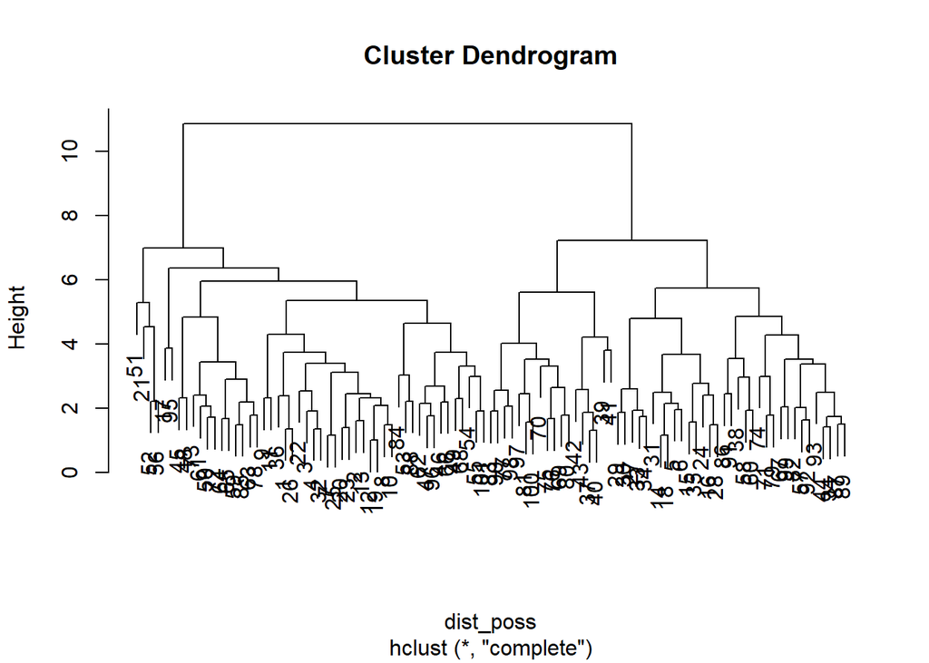

```r
dist_poss <- dist(dataset2)
res_poss <- hclust(dist_poss, method="complete")
plot(res_poss)
```

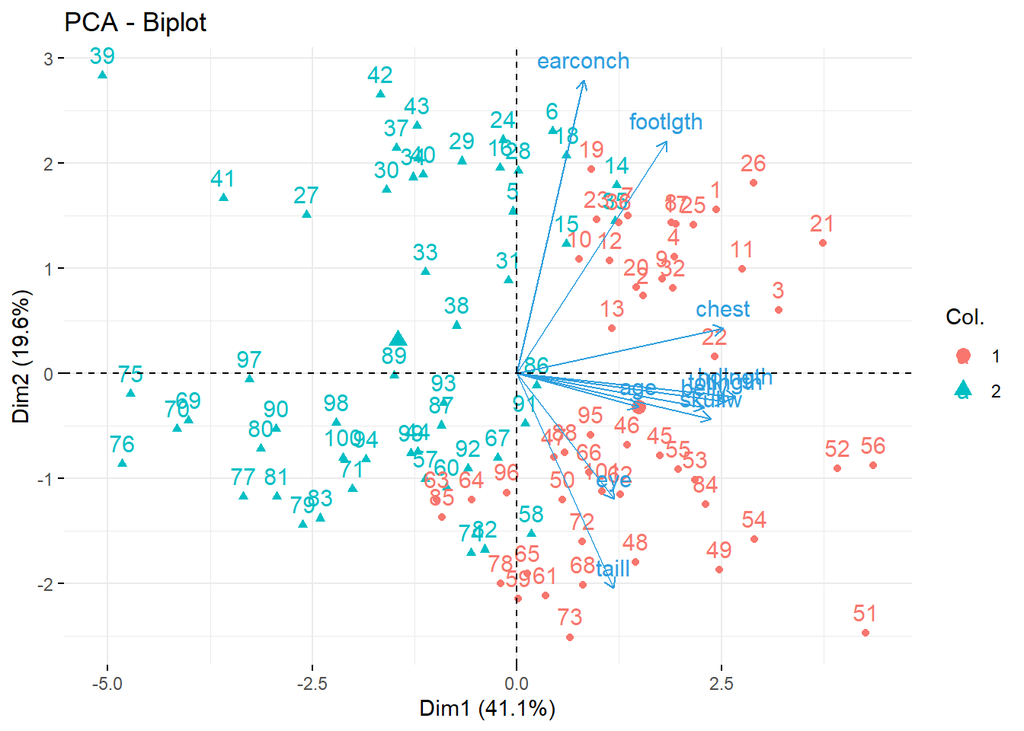

```r
cuts <- cutree(res_poss, h=8)
fviz_pca_biplot(pcaclust2, repel = FALSE,
                col.var = "#2E9FDF",
                col.ind = as.factor(cuts),
                )
```

Model-based. Посмотрим на лучшие модели по BIC. Видно, что лучше всего модели с 3 кластерами (одинаково ориентированные эллипсы с одинаковыми или разными объемами)

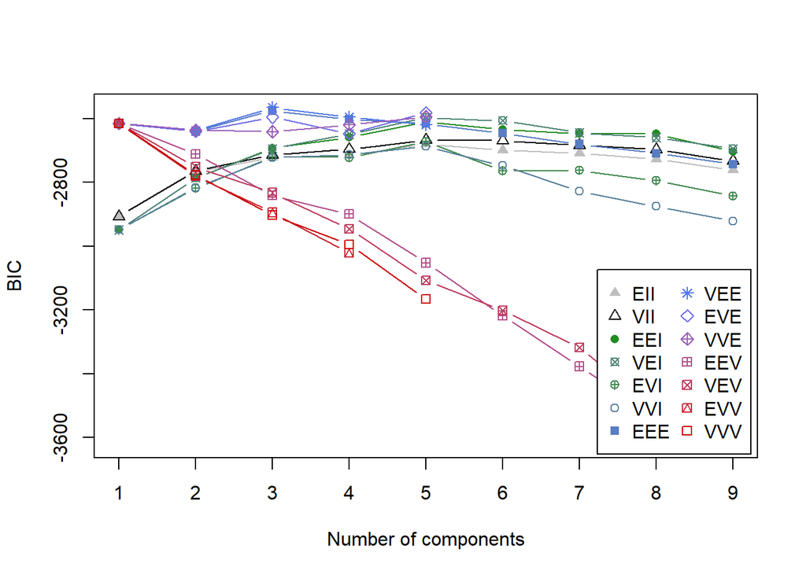

```r
BIC <- mclustBIC(dataset2)
plot(BIC)
```

```r
summary(BIC)
```

```
## Best BIC values:
##              VEE,3        EEE,3       EVE,5
## BIC      -2565.373 -2574.693522 -2581.40730
## BIC diff     0.000    -9.320474   -16.03426
```

Кластеризация, модель EEE.

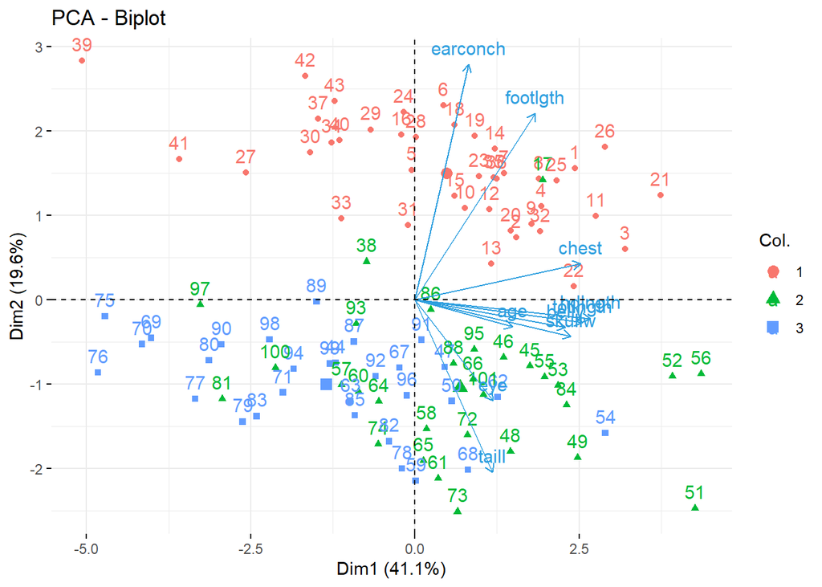

```r
res_poss3 <- Mclust(dataset2, method="EEE", G=3)
fviz_pca_biplot(pcaclust2, repel = FALSE,
                col.var = "#2E9FDF",
                col.ind = as.factor(res_poss3$classification),
                )
```

3 кластера в плоскости канонических переменных. Видно, что в данных на самом деле 3 класса. (Популяция other делится на 2)

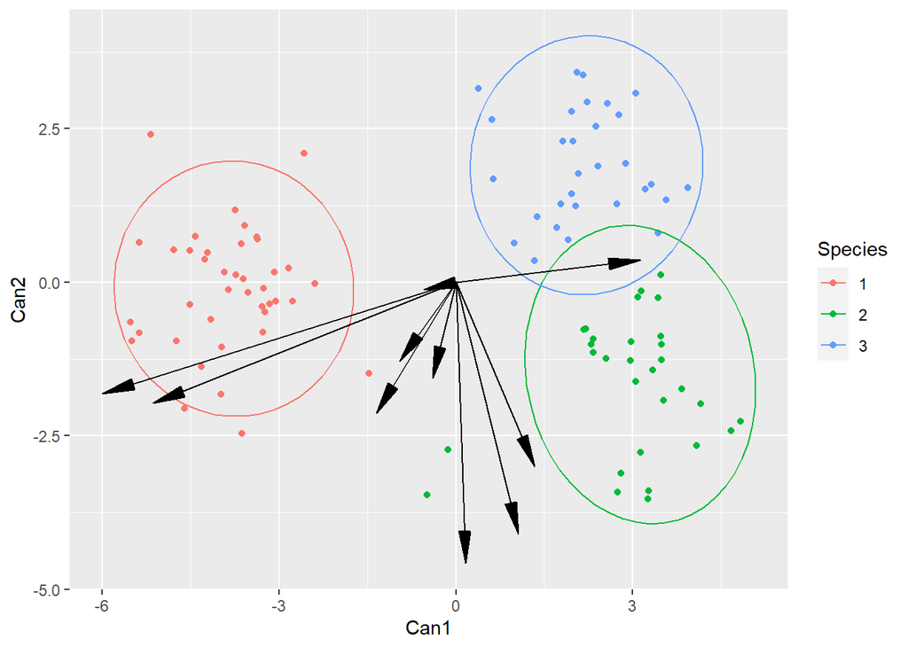

```r
dataset_can <- dataset2
dataset_can$Species <- as.factor(res_poss3$classification)
poss.manova <- manova(cbind(age,hdlngth,skullw,totlngth,taill,footlgth,earconch,eye,chest,belly) ~ Species, data = dataset_can)
result.candisc <- candisc(poss.manova)
ggplot(result.candisc$scores) +
    geom_point(aes(x = Can1, y = Can2, color = Species)) +
    stat_ellipse(aes(x = Can1, y = Can2, color = Species)) +
    geom_segment(as.data.frame(result.candisc$structure), mapping = aes(x = 0, y = 0, xend = 6.5 * Can1, yend = 6.5 * Can2), arrow = arrow(angle = 10, type = "closed"), size = 0.5)
```

Применение k-means и hclust для 3 классов не дает тех же результатов.

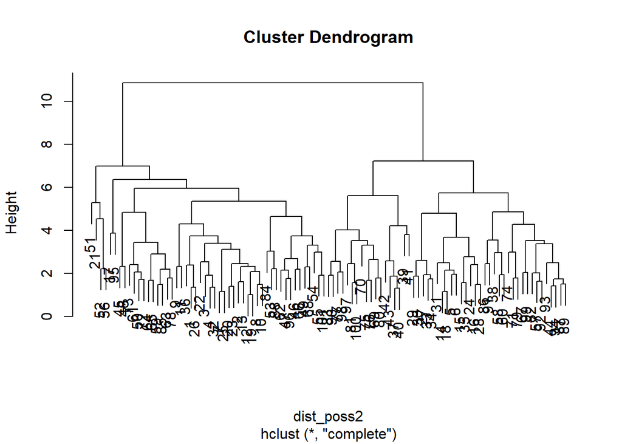

```r
dist_poss2 <- dist(dataset2)
res_poss2 <- hclust(dist_poss2, method="complete")
plot(res_poss2)
```

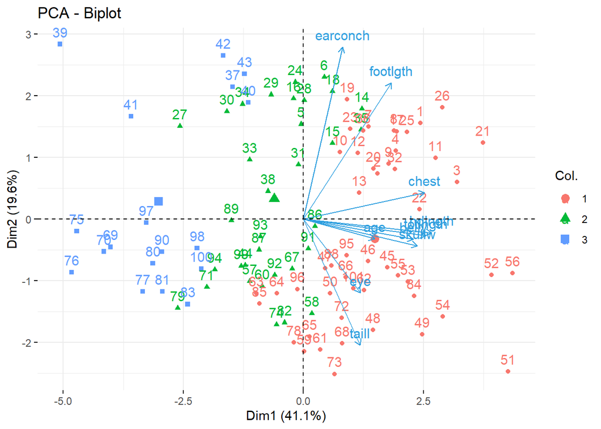

```r
cuts2 <- cutree(res_poss2, k=3)
fviz_pca_biplot(pcaclust2, repel = FALSE,
                col.var = "#2E9FDF",
                col.ind = as.factor(cuts2),
                )
```

```r
res22_3 <- kmeans(dataset2, centers=3, iter=100)
```

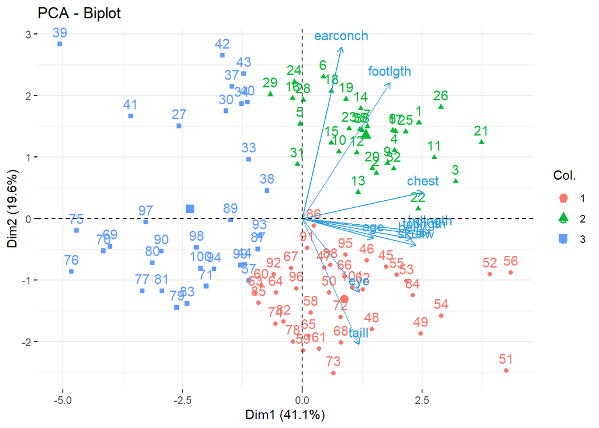

```r
fviz_pca_biplot(pcaclust2, repel = FALSE,
                col.var = "#2E9FDF",
                col.ind = as.factor(res22_3$cluster),
                )
```

Model-based для 2 классов.

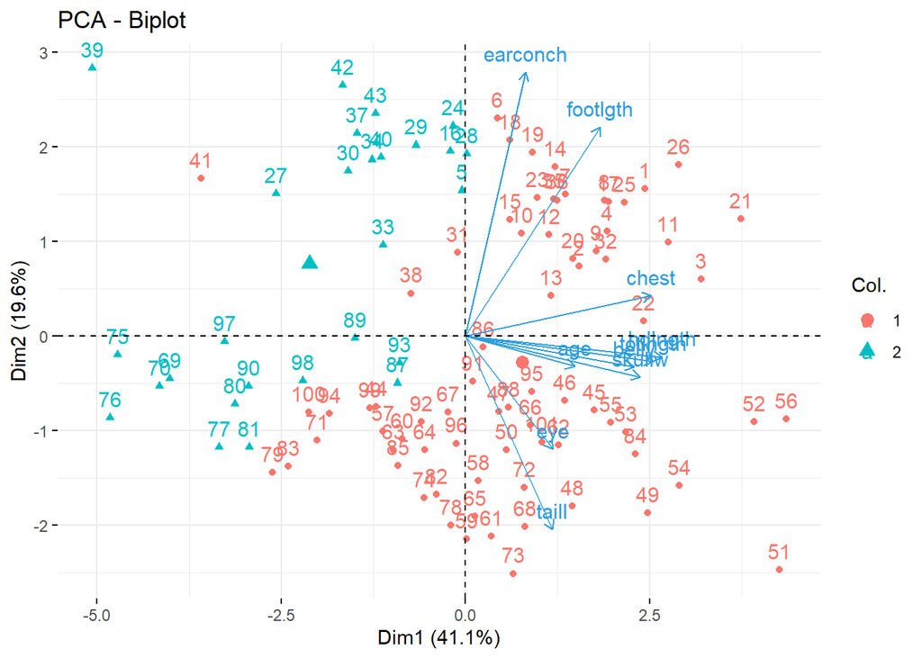

```r
res_poss32 <- Mclust(dataset2, method="VEE", G=2)
fviz_pca_biplot(pcaclust2, repel = FALSE,
                col.var = "#2E9FDF",
                col.ind = as.factor(res_poss32$classification),
                )
```

```r
Pops <- as.numeric(as.factor(dataset23$Pop))
```

Confusion matrix для Model-based.

```r
ct <- table(res_poss32$classification, Pops)
ct
```

```
##    Pops
##      1  2
##   1 45 29
##   2 13 14
```

```r
diag(prop.table(ct, 2))
```

```
##         1         2
## 0.7758621 0.3255814
```

Confusion matrix для k-means.

```r
ct2 <- table((res22$cluster)%%2+1, Pops)
ct2
```

```
##    Pops
##      1  2
##   1 29 12
##   2 29 31
```

```r
diag(prop.table(ct2, 2))
```

```
##         1         2
## 0.5000000 0.7209302
```

Confusion matrix для hclust.

```r
ct3 <- table(cuts, Pops)
ct3
```

```
##     Pops
## cuts  1  2
##    1 29 21
##    2 29 22
```

```r
diag(prop.table(ct3, 2))
```

```
##         1         2
## 0.5000000 0.5116279
```

С помощью model-based подхода удалось обнаружить, что в данных 3 популяции - популяция other содержит в себе 2 различающиеся группы.